# First visualizations Rmd

Soul Artists

Coen van den Elsen

## Corpus motivation

I want to research soul music. I am a musician myself and make soul/jazz/funk/RnB, I am curious how the music I listen and make everyday came to be and differce from earlier Thats why I decided to see how big soul artists through the years compare to eachother. As artists I have this list:

Erykah Badu, Steve Wonder, Bill Withers, Marvin Gaye, Ray charles, Aretha Franklin.

Tom Misch, Lianne De Havas, FKJ, Joy Crookes, Jorja Smith, Mahalia.

The first 6 are old, and the last 6 are new. I think these artists really represent the genre in their time and think it is a good representation of what I want to research. I do think more names could be added but I don’t think this would be of use. I may want to do a “middle” as well, but I am not sure who or what that is. I suspect the most difference will be seen in tempo and time, as most songs have been going faster and getting shorter through the years The tracks of all these artists will be compared, I think Bill Withers is the most atypical, because he does a lot of genres besides soul alone (like blues etc.)

### Plots

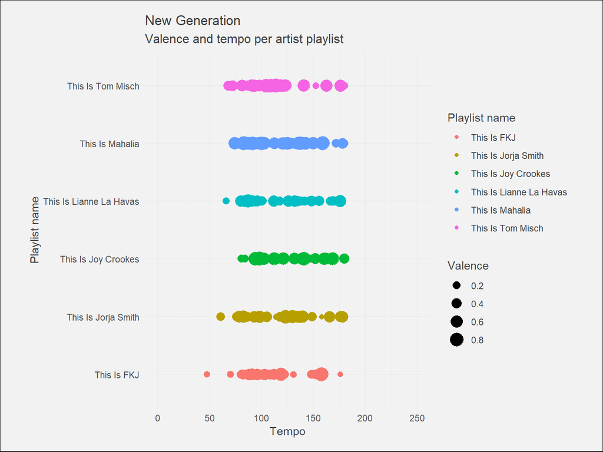

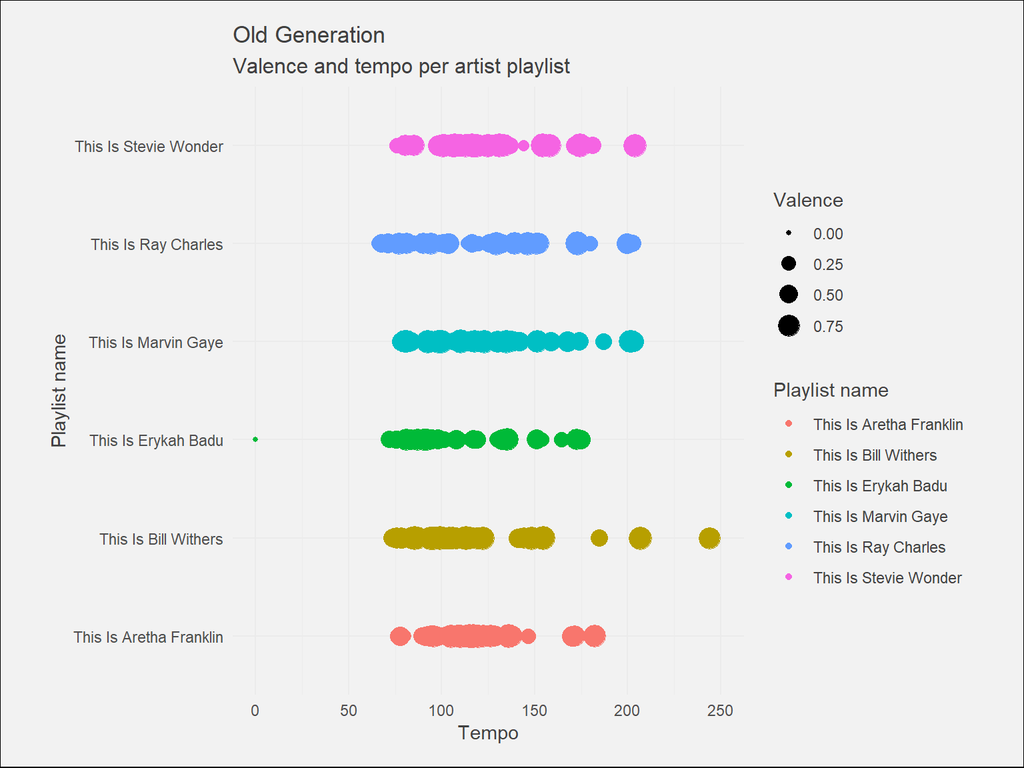

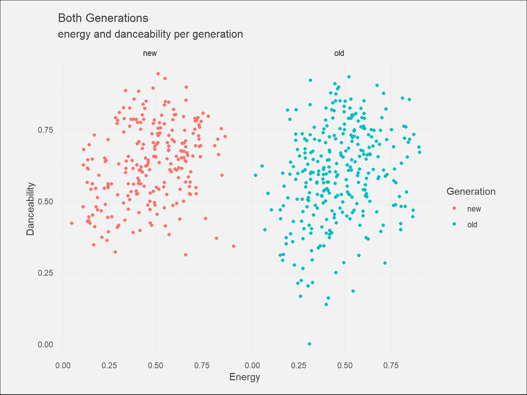

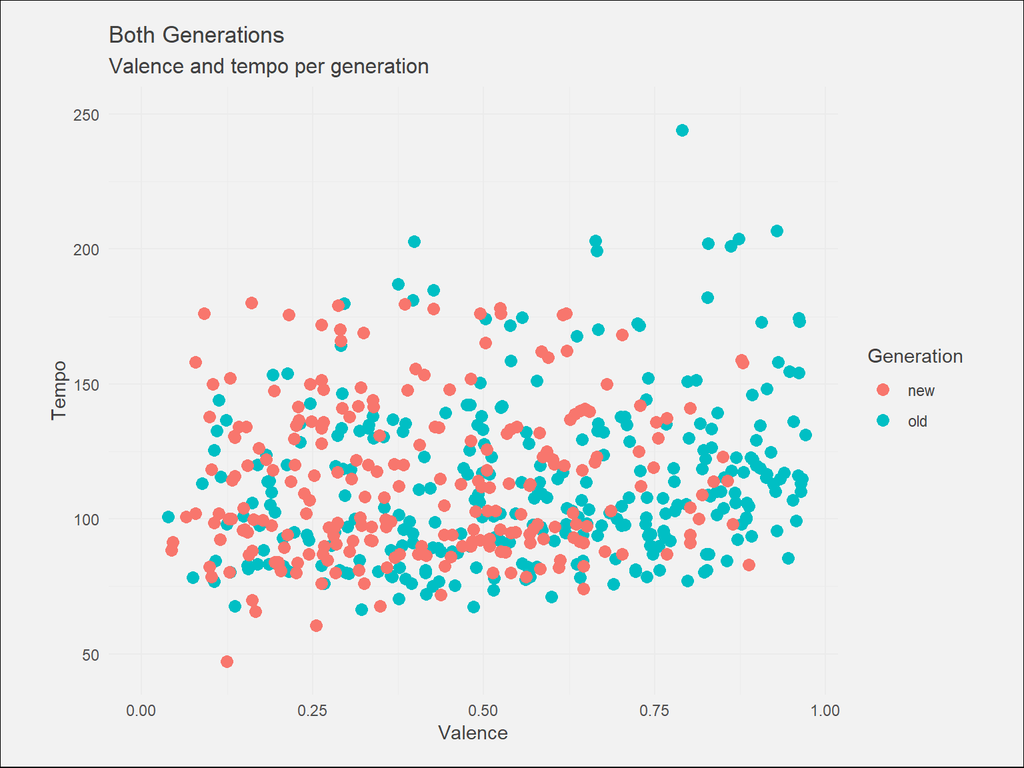

I could have included more data in the graphs, but this wouldnt lead to a more comprehendable result.

Interesting observations

What is interesting to see is that there is 1 outlier, a song of Erykah Badu. This one is called “Hi”, which is not a full song, but definitaly music, it is in the “This is Erykah Badu” playlist. This song has no data, valence and tempo are set to 0. Another interesting point is that 1 song of Bill Withers, Dont want you on my mind, has a very high tempo (240-250). There also was an oultier like “Hi” in the This is Mahalia playlist, but spotify took that one out during the time I was working on this assignment.